# final

```python
import re
import numpy as np
import pandas as pd
import seaborn as sns
import matplotlib.pyplot as plt
```

```python
use_intermediate_results=True
```

```python
!wget https://media.githubusercontent.com/media/metmuseum/openaccess/master/MetObjects.csv
```

[output not shown]

```python
museum=pd.read_csv('./MetObjects.csv')
```

## Dataset and motivation slide

Description of the dataset:

To the extent possible under law, The Metropolitan Museum of Art has waived all copyright and related or neighboring rights to this dataset using Creative Commons Zero. This work is published from: The United States Of America. You can also find the text of the CC Zero deed in the file LICENSE in this repository. These select datasets are now available for use in any media without permission or fee; they also include identifying data for artworks under copyright. The datasets support the search, use, and interaction with the Museum’s collection.

- **Object Number/Object ID**: a unique number sequence for each object in museum.
- **Is Highlight**: a bool to show whether an object is highlighted or not.
- **Is Public domain**: a bool to show whether an object is displayed in public domain or not.
- **Department**: the department the object belongs to.
- **Object name**: how the object called.
- **Title**: detailed object name with discription.
- **Culture/Period/Dynasty/Reign**: the background of each object.
- **Portfolio**: the portfolio the object belongs to.
- **Artist Pole/Artist Prefix/Artist Display Name/Artist Display Bio/Artist Suffix/Artist Alpha Sort/Artist Nationality/Artist Begin Date/Artist End Date**: all detailed artist background.
- **Object Date/Object Begin Date/Object End Date**: the display period of each object.
- **Medium**: the materials used to make the items.
- **Dimensions**: the dimension of each object.
- **Credit Line**: the credit information of each object.
- **Classification**: the category of material each objects belongs to.

## Literature review:

https://cloud.google.com/blog/products/gcp/when-art-meets-big-data-analyzing-200000-items-from-the-met-collection-in-bigquery

And here is what they made but we have not:

"Labels by time period" To start, let’s JOIN the time period for each piece of art from our metadata table with the labels returned by the Cloud Vision API’s label detection method. This query will give us the top 3 labels for each time period

"Analyzing the image data" Because art is visual, our analysis can only go so far by looking at metadata. We’ve got images for 200,000 pieces of art - that’s a lot of pixels! I took one image for each of our 200,000 pieces and sent it to the Cloud Vision API. Then I took the Cloud Vision API’s JSON response and stored the result in a BigQuery table. This gives us lots of information on each piece of art: what’s in the image, where the image can be found on the web, urls of similar images, and more. For details on how I processed these images, check out this post.

```python
museum
```

|  | Object Number | Is Highlight | Is Public Domain | Object ID | Department | Object Name | Title | Culture | Period | Dynasty | ... | Locale | Locus | Excavation | River | Classification | Rights and Reproduction | Link Resource | Metadata Date | Repository | Tags |
| --- | --- | --- | --- | --- | --- | --- | --- | --- | --- | --- | --- | --- | --- | --- | --- | --- | --- | --- | --- | --- | --- |
| 0 | 1979.486.1 | False | False | 1 | American Decorative Arts | Coin | One-dollar Liberty Head Coin | NaN | NaN | NaN | ... | NaN | NaN | NaN | NaN | Metal | NaN | http://www.metmuseum.org/art/collection/search/1 | 3/11/2019 8:00:00 AM | Metropolitan Museum of Art, New York, NY | NaN |
| 1 | 1980.264.5 | False | False | 2 | American Decorative Arts | Coin | Ten-dollar Liberty Head Coin | NaN | NaN | NaN | ... | NaN | NaN | NaN | NaN | Metal | NaN | http://www.metmuseum.org/art/collection/search/2 | 3/11/2019 8:00:00 AM | Metropolitan Museum of Art, New York, NY | NaN |
| 2 | 67.265.9 | False | False | 3 | American Decorative Arts | Coin | Two-and-a-Half Dollar Coin | NaN | NaN | NaN | ... | NaN | NaN | NaN | NaN | Metal | NaN | http://www.metmuseum.org/art/collection/search/3 | 3/11/2019 8:00:00 AM | Metropolitan Museum of Art, New York, NY | NaN |
| 3 | 67.265.10 | False | False | 4 | American Decorative Arts | Coin | Two-and-a-Half Dollar Coin | NaN | NaN | NaN | ... | NaN | NaN | NaN | NaN | Metal | NaN | http://www.metmuseum.org/art/collection/search/4 | 3/11/2019 8:00:00 AM | Metropolitan Museum of Art, New York, NY | NaN |
| 4 | 67.265.11 | False | False | 5 | American Decorative Arts | Coin | Two-and-a-Half Dollar Coin | NaN | NaN | NaN | ... | NaN | NaN | NaN | NaN | Metal | NaN | http://www.metmuseum.org/art/collection/search/5 | 3/11/2019 8:00:00 AM | Metropolitan Museum of Art, New York, NY | NaN |
| 5 | 67.265.12 | False | False | 6 | American Decorative Arts | Coin | Two-and-a-Half Dollar Coin | NaN | NaN | NaN | ... | NaN | NaN | NaN | NaN | Metal | NaN | http://www.metmuseum.org/art/collection/search/6 | 3/11/2019 8:00:00 AM | Metropolitan Museum of Art, New York, NY | NaN |
| 6 | 67.265.13 | False | False | 7 | American Decorative Arts | Coin | Two-and-a-Half Dollar Coin | NaN | NaN | NaN | ... | NaN | NaN | NaN | NaN | Metal | NaN | http://www.metmuseum.org/art/collection/search/7 | 3/11/2019 8:00:00 AM | Metropolitan Museum of Art, New York, NY | Birds\|Coins |
| 7 | 67.265.14 | False | False | 8 | American Decorative Arts | Coin | Two-and-a-Half Dollar Coin | NaN | NaN | NaN | ... | NaN | NaN | NaN | NaN | Metal | NaN | http://www.metmuseum.org/art/collection/search/8 | 3/11/2019 8:00:00 AM | Metropolitan Museum of Art, New York, NY | Inscriptions\|Men\|Profiles\|Coins |
| 8 | 67.265.15 | False | False | 9 | American Decorative Arts | Coin | Two-and-a-Half Dollar Coin | NaN | NaN | NaN | ... | NaN | NaN | NaN | NaN | Metal | NaN | http://www.metmuseum.org/art/collection/search/9 | 3/11/2019 8:00:00 AM | Metropolitan Museum of Art, New York, NY | NaN |
| 9 | 1979.486.3 | False | False | 10 | American Decorative Arts | Coin | Two-and-a-half-dollar Indian Head Coin | NaN | NaN | NaN | ... | NaN | NaN | NaN | NaN | Metal | NaN | http://www.metmuseum.org/art/collection/search/10 | 3/11/2019 8:00:00 AM | Metropolitan Museum of Art, New York, NY | NaN |
| 10 | 1979.486.2 | False | False | 11 | American Decorative Arts | Coin | Two-and-a-half-dollar Liberty Head Coin | NaN | NaN | NaN | ... | NaN | NaN | NaN | NaN | Metal | NaN | http://www.metmuseum.org/art/collection/search/11 | 3/11/2019 8:00:00 AM | Metropolitan Museum of Art, New York, NY | NaN |
| 11 | 1979.486.7 | False | False | 12 | American Decorative Arts | Coin | Twenty-dollar Liberty Head Coin | NaN | NaN | NaN | ... | NaN | NaN | NaN | NaN | Metal | NaN | http://www.metmuseum.org/art/collection/search/12 | 3/11/2019 8:00:00 AM | Metropolitan Museum of Art, New York, NY | NaN |
| 12 | 1979.486.4 | False | False | 13 | American Decorative Arts | Coin | Five-dollar Indian Head Coin | NaN | NaN | NaN | ... | NaN | NaN | NaN | NaN | Metal | NaN | http://www.metmuseum.org/art/collection/search/13 | 3/11/2019 8:00:00 AM | Metropolitan Museum of Art, New York, NY | NaN |
| 13 | 1979.486.5 | False | False | 14 | American Decorative Arts | Coin | Five-dollar Liberty Head Coin | NaN | NaN | NaN | ... | NaN | NaN | NaN | NaN | Metal | NaN | http://www.metmuseum.org/art/collection/search/14 | 3/11/2019 8:00:00 AM | Metropolitan Museum of Art, New York, NY | NaN |
| 14 | 16.74.49 | False | False | 15 | American Decorative Arts | Coin | Coin, 1/2 Real | Mexican | NaN | NaN | ... | NaN | NaN | NaN | NaN | Silver | NaN | http://www.metmuseum.org/art/collection/search/15 | 3/11/2019 8:00:00 AM | Metropolitan Museum of Art, New York, NY | NaN |
| 15 | 16.74.27 | False | False | 16 | American Decorative Arts | Peso | Coin, 1/4 Peso | Mexican | NaN | NaN | ... | NaN | NaN | NaN | NaN | Metal | NaN | http://www.metmuseum.org/art/collection/search/16 | 3/11/2019 8:00:00 AM | Metropolitan Museum of Art, New York, NY | NaN |
| 16 | 16.74.28 | False | False | 17 | American Decorative Arts | Peso | Coin, 1/4 Peso | Mexican | NaN | NaN | ... | NaN | NaN | NaN | NaN | Metal | NaN | http://www.metmuseum.org/art/collection/search/17 | 3/11/2019 8:00:00 AM | Metropolitan Museum of Art, New York, NY | NaN |
| 17 | 16.74.29 | False | False | 18 | American Decorative Arts | Peso | Coin, 1/4 Peso | Mexican | NaN | NaN | ... | NaN | NaN | NaN | NaN | Metal | NaN | http://www.metmuseum.org/art/collection/search/18 | 3/11/2019 8:00:00 AM | Metropolitan Museum of Art, New York, NY | NaN |
| 18 | 16.74.30 | False | False | 19 | American Decorative Arts | Peso | Coin, 1/4 Peso | Mexican | NaN | NaN | ... | NaN | NaN | NaN | NaN | Metal | NaN | http://www.metmuseum.org/art/collection/search/19 | 3/11/2019 8:00:00 AM | Metropolitan Museum of Art, New York, NY | NaN |
| 19 | 16.74.31 | False | False | 20 | American Decorative Arts | Peso | Coin, 1/4 Peso | Mexican | NaN | NaN | ... | NaN | NaN | NaN | NaN | Metal | NaN | http://www.metmuseum.org/art/collection/search/20 | 3/11/2019 8:00:00 AM | Metropolitan Museum of Art, New York, NY | NaN |
| 20 | 16.74.32 | False | False | 21 | American Decorative Arts | Peso | Coin, 1/4 Peso | Mexican | NaN | NaN | ... | NaN | NaN | NaN | NaN | Metal | NaN | http://www.metmuseum.org/art/collection/search/21 | 3/11/2019 8:00:00 AM | Metropolitan Museum of Art, New York, NY | NaN |
| 21 | 16.74.43 | False | False | 22 | American Decorative Arts | Coin | Coin, 1/4 Real | Guatemalan | NaN | NaN | ... | NaN | NaN | NaN | NaN | Silver | NaN | http://www.metmuseum.org/art/collection/search/22 | 3/11/2019 8:00:00 AM | Metropolitan Museum of Art, New York, NY | NaN |
| 22 | 16.74.44 | False | False | 23 | American Decorative Arts | Coin | Coin, 1/4 Real | Guatemalan | NaN | NaN | ... | NaN | NaN | NaN | NaN | Silver | NaN | http://www.metmuseum.org/art/collection/search/23 | 3/11/2019 8:00:00 AM | Metropolitan Museum of Art, New York, NY | NaN |
| 23 | 16.74.33 | False | False | 24 | American Decorative Arts | Centavos | Coin, 10 Centavos | Mexican | NaN | NaN | ... | NaN | NaN | NaN | NaN | Metal | NaN | http://www.metmuseum.org/art/collection/search/24 | 3/11/2019 8:00:00 AM | Metropolitan Museum of Art, New York, NY | NaN |
| 24 | 16.74.34 | False | False | 25 | American Decorative Arts | Centavos | Coin, 10 Centavos | Mexican | NaN | NaN | ... | NaN | NaN | NaN | NaN | Metal | NaN | http://www.metmuseum.org/art/collection/search/25 | 3/11/2019 8:00:00 AM | Metropolitan Museum of Art, New York, NY | NaN |
| 25 | 16.74.35 | False | False | 26 | American Decorative Arts | Centavos | Coin, 10 Centavos | Mexican | NaN | NaN | ... | NaN | NaN | NaN | NaN | Metal | NaN | http://www.metmuseum.org/art/collection/search/26 | 3/11/2019 8:00:00 AM | Metropolitan Museum of Art, New York, NY | NaN |
| 26 | 16.74.36 | False | False | 27 | American Decorative Arts | Centavos | Coin, 10 Centavos | Mexican | NaN | NaN | ... | NaN | NaN | NaN | NaN | Metal | NaN | http://www.metmuseum.org/art/collection/search/27 | 3/11/2019 8:00:00 AM | Metropolitan Museum of Art, New York, NY | NaN |
| 27 | 16.74.38 | False | False | 28 | American Decorative Arts | Centavos | Coin, 10 Centavos | Mexican | NaN | NaN | ... | NaN | NaN | NaN | NaN | Metal | NaN | http://www.metmuseum.org/art/collection/search/28 | 3/11/2019 8:00:00 AM | Metropolitan Museum of Art, New York, NY | NaN |
| 28 | 16.74.39 | False | False | 29 | American Decorative Arts | Centavos | Coin, 10 Centavos | Mexican | NaN | NaN | ... | NaN | NaN | NaN | NaN | Metal | NaN | http://www.metmuseum.org/art/collection/search/29 | 3/11/2019 8:00:00 AM | Metropolitan Museum of Art, New York, NY | NaN |
| 29 | 16.74.37 | False | False | 30 | American Decorative Arts | Centavos | Coin, 10 Centavos | Mexican | NaN | NaN | ... | NaN | NaN | NaN | NaN | Metal | NaN | http://www.metmuseum.org/art/collection/search/30 | 3/11/2019 8:00:00 AM | Metropolitan Museum of Art, New York, NY | NaN |
| ... | ... | ... | ... | ... | ... | ... | ... | ... | ... | ... | ... | ... | ... | ... | ... | ... | ... | ... | ... | ... | ... |
| 492420 | Burdick 537(32) | False | False | 822548 | Drawings and Prints | Album | Album 537, Page 32 | NaN | NaN | NaN | ... | NaN | NaN | NaN | NaN | Albums\|Ephemera | NaN | http://www.metmuseum.org/art/collection/search... | 3/11/2019 8:00:00 AM | Metropolitan Museum of Art, New York, NY | NaN |
| 492421 | Burdick 537, R95.21 | False | False | 822549 | Drawings and Prints | Print | Gary Cooper from Movie Star Portraits (Emo Mov... | NaN | NaN | NaN | ... | NaN | NaN | NaN | NaN | Prints\|Ephemera | NaN | http://www.metmuseum.org/art/collection/search... | 3/11/2019 8:00:00 AM | Metropolitan Museum of Art, New York, NY | NaN |
| 492422 | Burdick 537, R95.22 | False | False | 822550 | Drawings and Prints | Print | Jackie Cooper from Movie Star Portraits (Emo M... | NaN | NaN | NaN | ... | NaN | NaN | NaN | NaN | Prints\|Ephemera | NaN | http://www.metmuseum.org/art/collection/search... | 3/11/2019 8:00:00 AM | Metropolitan Museum of Art, New York, NY | NaN |
| 492423 | Burdick 537(33) | False | False | 822551 | Drawings and Prints | Album | Album 537, Page 33 | NaN | NaN | NaN | ... | NaN | NaN | NaN | NaN | Albums\|Ephemera | NaN | http://www.metmuseum.org/art/collection/search... | 3/11/2019 8:00:00 AM | Metropolitan Museum of Art, New York, NY | NaN |
| 492424 | Burdick 537, R95.23 | False | False | 822552 | Drawings and Prints | Print | Dolores Costello from Movie Star Portraits (Em... | NaN | NaN | NaN | ... | NaN | NaN | NaN | NaN | Prints\|Ephemera | NaN | http://www.metmuseum.org/art/collection/search... | 3/11/2019 8:00:00 AM | Metropolitan Museum of Art, New York, NY | NaN |
| 492425 | Burdick 537, R95.24 | False | False | 822553 | Drawings and Prints | Print | Joan Crawford from Movie Star Portraits (Emo M... | NaN | NaN | NaN | ... | NaN | NaN | NaN | NaN | Prints\|Ephemera | NaN | http://www.metmuseum.org/art/collection/search... | 3/11/2019 8:00:00 AM | Metropolitan Museum of Art, New York, NY | NaN |
| 492426 | Burdick 537(34) | False | False | 822554 | Drawings and Prints | Album | Album 537, Page 34 | NaN | NaN | NaN | ... | NaN | NaN | NaN | NaN | Albums\|Ephemera | NaN | http://www.metmuseum.org/art/collection/search... | 3/11/2019 8:00:00 AM | Metropolitan Museum of Art, New York, NY | NaN |
| 492427 | Burdick 537, R95.25 | False | False | 822556 | Drawings and Prints | Print | Bing Crosby from Movie Star Portraits (Emo Mov... | NaN | NaN | NaN | ... | NaN | NaN | NaN | NaN | Prints\|Ephemera | NaN | http://www.metmuseum.org/art/collection/search... | 3/11/2019 8:00:00 AM | Metropolitan Museum of Art, New York, NY | NaN |
| 492428 | Burdick 537, R95.26 | False | False | 822557 | Drawings and Prints | Print | Bette Davis from Movie Star Portraits (Emo Mov... | NaN | NaN | NaN | ... | NaN | NaN | NaN | NaN | Prints\|Ephemera | NaN | http://www.metmuseum.org/art/collection/search... | 3/11/2019 8:00:00 AM | Metropolitan Museum of Art, New York, NY | NaN |
| 492429 | Burdick 537(35) | False | False | 822558 | Drawings and Prints | Album | Album 537, Page 35 | NaN | NaN | NaN | ... | NaN | NaN | NaN | NaN | Albums\|Ephemera | NaN | http://www.metmuseum.org/art/collection/search... | 3/11/2019 8:00:00 AM | Metropolitan Museum of Art, New York, NY | NaN |
| 492430 | 62.607 | False | False | 822559 | Drawings and Prints | Print | Proposed Design for U.S. Postage Stamp: 4¢ | NaN | NaN | NaN | ... | NaN | NaN | NaN | NaN | Prints | NaN | http://www.metmuseum.org/art/collection/search... | 3/11/2019 8:00:00 AM | Metropolitan Museum of Art, New York, NY | NaN |
| 492431 | 07.225.162b | False | True | 822561 | European Sculpture and Decorative Arts | Overdoor panel | Overdoor panel with allegory of Science (one o... | French | NaN | NaN | ... | NaN | NaN | NaN | NaN | Woodwork | NaN | http://www.metmuseum.org/art/collection/search... | 3/11/2019 8:00:00 AM | Metropolitan Museum of Art, New York, NY | Women\|Putti\|Scales |
| 492432 | 28.99.29 | False | True | 822562 | Arms and Armor | Crossbow nut\r\n | Crossbow Nut | Western European or Near Eastern | NaN | NaN | ... | NaN | NaN | NaN | NaN | Archery Equipment | NaN | http://www.metmuseum.org/art/collection/search... | 3/11/2019 8:00:00 AM | Metropolitan Museum of Art, New York, NY | Tools and Equipment |
| 492433 | 28.99.31 | False | False | 822563 | Arms and Armor | Crossbow bolt head | Crossbow Bolt Head | Western European or Near Eastern | NaN | NaN | ... | NaN | NaN | NaN | NaN | Archery Equipment-Arrowheads | NaN | http://www.metmuseum.org/art/collection/search... | 3/11/2019 8:00:00 AM | Metropolitan Museum of Art, New York, NY | NaN |
| 492434 | 28.99.32 | False | False | 822564 | Arms and Armor | Crossbow bolt head | Crossbow Bolt Head | Western European or Near Eastern | NaN | NaN | ... | NaN | NaN | NaN | NaN | Archery Equipment-Arrowheads | NaN | http://www.metmuseum.org/art/collection/search... | 3/11/2019 8:00:00 AM | Metropolitan Museum of Art, New York, NY | NaN |
| 492435 | 33.35.90 | False | False | 822565 | Drawings and Prints | Print | Le Jeu Ne Vaut Pas La Chandelle (The Game is N... | NaN | NaN | NaN | ... | NaN | NaN | NaN | NaN | Prints | NaN | http://www.metmuseum.org/art/collection/search... | 3/11/2019 8:00:00 AM | Metropolitan Museum of Art, New York, NY | NaN |
| 492436 | 33.35.84 | False | False | 822566 | Drawings and Prints | Print | Santa Claus and Little Bo Peep | NaN | NaN | NaN | ... | NaN | NaN | NaN | NaN | Prints | NaN | http://www.metmuseum.org/art/collection/search... | 3/11/2019 8:00:00 AM | Metropolitan Museum of Art, New York, NY | NaN |
| 492437 | 33.35.85 | False | False | 822567 | Drawings and Prints | Print | A Stocking Full | NaN | NaN | NaN | ... | NaN | NaN | NaN | NaN | Prints | NaN | http://www.metmuseum.org/art/collection/search... | 3/11/2019 8:00:00 AM | Metropolitan Museum of Art, New York, NY | NaN |
| 492438 | 33.35.111 | False | False | 822568 | Drawings and Prints | Print | A Merry Christmas | NaN | NaN | NaN | ... | NaN | NaN | NaN | NaN | Prints | NaN | http://www.metmuseum.org/art/collection/search... | 3/11/2019 8:00:00 AM | Metropolitan Museum of Art, New York, NY | NaN |
| 492439 | 33.35.112 | False | False | 822569 | Drawings and Prints | Print | A Merry Christmas | NaN | NaN | NaN | ... | NaN | NaN | NaN | NaN | Prints | NaN | http://www.metmuseum.org/art/collection/search... | 3/11/2019 8:00:00 AM | Metropolitan Museum of Art, New York, NY | NaN |
| 492440 | 33.35.92 | False | False | 822570 | Drawings and Prints | Print | Wilde on Us. Something To "Live Up" To in America | NaN | NaN | NaN | ... | NaN | NaN | NaN | NaN | Prints | NaN | http://www.metmuseum.org/art/collection/search... | 3/11/2019 8:00:00 AM | Metropolitan Museum of Art, New York, NY | NaN |
| 492441 | 33.35.93 | False | False | 822571 | Drawings and Prints | Print | Oscar at the Sea-Shore | NaN | NaN | NaN | ... | NaN | NaN | NaN | NaN | Prints | NaN | http://www.metmuseum.org/art/collection/search... | 3/11/2019 8:00:00 AM | Metropolitan Museum of Art, New York, NY | NaN |
| 492442 | 24.58.27 | False | False | 822593 | Drawings and Prints | Print | Village Square, Cagnes | NaN | NaN | NaN | ... | NaN | NaN | NaN | NaN | Prints | NaN | http://www.metmuseum.org/art/collection/search... | 3/11/2019 8:00:00 AM | Metropolitan Museum of Art, New York, NY | NaN |
| 492443 | 26.28.479 | False | False | 822594 | Drawings and Prints | Print, Trade Card | Trade Card for Martin Bossange & Co., Bookseller | NaN | NaN | NaN | ... | NaN | NaN | NaN | NaN | Prints\|Ephemera | NaN | http://www.metmuseum.org/art/collection/search... | 3/11/2019 8:00:00 AM | Metropolitan Museum of Art, New York, NY | NaN |
| 492444 | 22.106.37(6) | False | False | 822596 | Drawings and Prints | Print | Head of an Old Arab Man | NaN | NaN | NaN | ... | NaN | NaN | NaN | NaN | Prints | NaN | http://www.metmuseum.org/art/collection/search... | 3/11/2019 8:00:00 AM | Metropolitan Museum of Art, New York, NY | NaN |
| 492445 | 17.3.756–1539 | False | False | 822597 | Drawings and Prints | Print | Portrait of Cecil Lawson | NaN | NaN | NaN | ... | NaN | NaN | NaN | NaN | Prints | NaN | http://www.metmuseum.org/art/collection/search... | 3/11/2019 8:00:00 AM | Metropolitan Museum of Art, New York, NY | NaN |
| 492446 | 44.91.839 | False | False | 822598 | Drawings and Prints | Print | Hubert Herkomer A.R.A. and His Children | NaN | NaN | NaN | ... | NaN | NaN | NaN | NaN | Prints | NaN | http://www.metmuseum.org/art/collection/search... | 3/11/2019 8:00:00 AM | Metropolitan Museum of Art, New York, NY | NaN |
| 492447 | 64.682.348 | False | False | 822599 | Drawings and Prints | Print | A Welsh Woman | NaN | NaN | NaN | ... | NaN | NaN | NaN | NaN | Prints | NaN | http://www.metmuseum.org/art/collection/search... | 3/11/2019 8:00:00 AM | Metropolitan Museum of Art, New York, NY | NaN |
| 492448 | 64.682.347 | False | False | 822600 | Drawings and Prints | Print | Invitation to a Benefit Dinner from Hubert von... | NaN | NaN | NaN | ... | NaN | NaN | NaN | NaN | Prints | NaN | http://www.metmuseum.org/art/collection/search... | 3/11/2019 8:00:00 AM | Metropolitan Museum of Art, New York, NY | NaN |
| 492449 | 59.500.541 | False | False | 822601 | Drawings and Prints | Print | The Tents | NaN | NaN | NaN | ... | NaN | NaN | NaN | NaN | Prints | NaN | http://www.metmuseum.org/art/collection/search... | 3/11/2019 8:00:00 AM | Metropolitan Museum of Art, New York, NY | NaN |

492450 rows × 44 columns

## Research Question

We are trying to solve the problems in real-world as follows:

1.Count the production time of each artwork to get the distributions of these in the timeline.

Input:the column 'artist begin date'.

Output:the visual of the numbers of the artists by the timeline.

2.Count the origins of each artwork to get the distributions of the artworks in the world.

Input:the column 'Region'.

Output:the visual which plots the top ten amounts of the location.

3.Count the number of medium of the objects.

Input:the column 'Medium'.

Output:the visual which plots the top twenty amounts of the medium.

So,there are three important attributes which should be collected from the dataframe:location time and medium.

Because that,we just need several columns.

Because that,some columns in this csv are not needed.

```python
museum=museum[['Artist Begin Date','Region','Medium','Is Highlight','Is Public Domain']].copy()
museum.head(50)
```

|  | Artist Begin Date | Region | Medium | Is Highlight | Is Public Domain |
| --- | --- | --- | --- | --- | --- |
| 0 | 1794 | NaN | Gold | False | False |
| 1 | 1785 | NaN | Gold | False | False |
| 2 | NaN | NaN | Gold | False | False |
| 3 | NaN | NaN | Gold | False | False |
| 4 | NaN | NaN | Gold | False | False |
| 5 | NaN | NaN | Gold | False | False |
| 6 | NaN | NaN | Gold | False | False |
| 7 | NaN | NaN | Gold | False | False |
| 8 | NaN | NaN | Gold | False | False |
| 9 | 1867 | NaN | Gold | False | False |
| 10 | 1785 | NaN | Gold | False | False |
| 11 | 1794 | NaN | Gold | False | False |
| 12 | 1867 | NaN | Gold | False | False |
| 13 | 1785 | NaN | Gold | False | False |
| 14 | NaN | NaN | Silver | False | False |
| 15 | NaN | NaN | Bronze or copper | False | False |
| 16 | NaN | NaN | Bronze or copper | False | False |
| 17 | NaN | NaN | Bronze or copper | False | False |
| 18 | NaN | NaN | Bronze or copper | False | False |
| 19 | NaN | NaN | Bronze or copper | False | False |
| 20 | NaN | NaN | Bronze or copper | False | False |
| 21 | NaN | NaN | Silver | False | False |
| 22 | NaN | NaN | Silver | False | False |
| 23 | NaN | NaN | Nickel | False | False |
| 24 | NaN | NaN | Nickel | False | False |
| 25 | NaN | NaN | Nickel | False | False |
| 26 | NaN | NaN | Nickel | False | False |
| 27 | NaN | NaN | Nickel | False | False |
| 28 | NaN | NaN | Nickel | False | False |
| 29 | NaN | NaN | Nickel | False | False |
| 30 | NaN | NaN | Nickel | False | False |
| 31 | NaN | NaN | Gold | False | False |
| 32 | 1861 | NaN | Pressed glass | False | False |
| 33 | 1835 | NaN | Mahogany, laminated | False | True |
| 34 | 1859 \|1837 | NaN | Gold, amethysts, spessartites, tourmalines, fr... | False | False |
| 35 | 1885 | NaN | Oak, tulip poplar | False | False |
| 36 | 1765 | NaN | Earthenware, basalt | False | True |
| 37 | 1765 | NaN | Earthenware, basalt | False | True |
| 38 | NaN | NaN | Paper | False | True |
| 39 | 1818 | NaN | Pressed glass | False | True |
| 40 | NaN | NaN | Pressed glass | False | True |
| 41 | NaN | NaN | Brass, iron | False | True |
| 42 | NaN | NaN | Brass, iron | False | True |
| 43 | NaN | NaN | Brass | False | True |
| 44 | NaN | NaN | Brass | False | True |
| 45 | NaN | NaN | Brass | False | True |
| 46 | NaN | NaN | Brass | False | True |
| 47 | NaN | NaN | Iron | False | False |
| 48 | NaN | NaN | Iron | False | False |
| 49 | NaN | NaN | Iron | False | True |

Here are the types of every columns:

```python
museum.dtypes
```

```
Artist Begin Date    object
Region               object
Medium               object
Is Highlight           bool
Is Public Domain       bool
dtype: object
```

Some of them have wrong datatypes.But first,we should solve the NaN value in every column.

Let's finish the first goal:Count the production time of each artwork to get the distributions of these in the timeline.

First,we need to clean the values in this column,and in it there are two main problems:NaN value and two time values in one row.

```python
museum['Artist Begin Date'].unique()
```

```
array(['1794      ', '1785      ', nan, ..., '1840      |1854      ',
       '1855      |1849      |1849      |1850      ',
       '1849      |1849      |1877      |1874      '], dtype=object)
```

```python
museum=museum.fillna({'Artist Begin Date':0})
artist_date=[]
for i in range(len(museum['Artist Begin Date'])):
    if type(museum['Artist Begin Date'][i])==int:
        pass
    else:
        museum['Artist Begin Date'][i]=museum['Artist Begin Date'][i][:4]
        artist_date.append(int(museum['Artist Begin Date'][i]))
```

Because the running time is too long(2 hours),so we keep the results in a csv file --artist _date.csv

```python
!wget https://github.com/tcj1995/final-project/blob/master/artist%20_date.csv
```

```python
date=pd.read_csv('./artist _date.csv')
artist_date=[]
for i in range(len(date)):
    artist_date.append(date['1794'][i])
```

After cleaning,let's change the type of this column.

```python
museum['Artist Begin Date']=museum['Artist Begin Date'].astype(int)
```

```python
museum.dtypes
```

[output not shown]

Now,we want to see the exactly number of artists in every year.

```python
set_date=set(artist_date)
d={}
for item in set_date:
     d.update({item:artist_date.count(item)})
a = sorted(d.items(), key=lambda x: x[1], reverse=True)
a.sort()
```

From the sorted result,we find that some numbers is too small to be caught in the plot,so we decide to use the numbers which are big to make the graph.

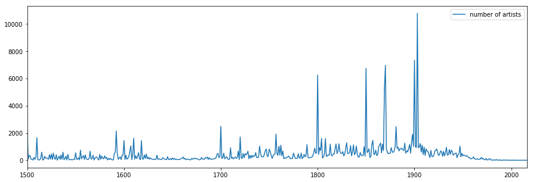

```python
for k in reversed(range(len(a))):
    if a[k][0]<1500:
        a.remove(a[k])
    else:
        pass
summary_statistics_tenmax_artist_year=a[:]
year=[]
number=[]
for i in range(len(summary_statistics_tenmax_artist_year)):
    year.append(summary_statistics_tenmax_artist_year[i][0])
    number.append(summary_statistics_tenmax_artist_year[i][1])
df_1=pd.DataFrame(number,year,columns=['number of artists'])
df_1.plot(figsize=(15,5))
```

We can use the line chart to get the highest number for the summary statistics.And we can use the distplot to understand the trend of the number.

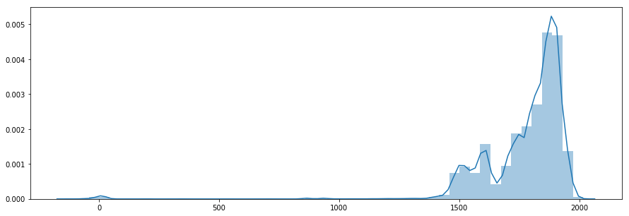

```python
plt.figure(figsize=(15,5))
sns.distplot(artist_date)
```

From this two graph,we can get two conclusions:

1.About 1900,the number of the artists is going to the peak value.

2.The trend of the number of the artists is smooth until 1500, and from 1500 to 1900 it goes up apprently.

Next part, we want to know which area uses the most number of different medium.We should use two columns together "Medium" "Region"

```python
d={}
museum=museum.fillna({'Medium':'unknown'})
museum=museum.fillna({'Region':'unknown_place'})
for i in range(len(museum)):
    if museum['Medium'][i]=='unknown' or museum['Region'][i]=='unknown_place':
        pass
    else:
        regex=re.compile(r'\w+')
        a=regex.findall(museum['Region'][i])
        b=regex.findall(museum['Medium'][i])
        d.update({' '.join(b): ' '.join(a)})
```

```python
set_regions=set()
for item in d.values():
    set_regions.add(item)
set_regions=list(set_regions)
d2={}
for i in range(len(set_regions)):
    d2.update({set_regions[i]:[]})
for key,value in d.items():
    if value in d2.keys():
         d2[value].append(key)
    else:
        d2[value]=[]
summary_statistics_region_medium = sorted(d2.items(), key=lambda x: len(x[1]), reverse=True)
summary_statistics_region_medium[:20]
```

```
[('Upper Egypt Thebes',
  ['Leather',
   'Bone',
   'Ivory paint',
   'Ivory pigment',
   'Wood paint',
   'Wax',
   'Serpentine',
   'Fiber',
   'Green schist',
   'Wood string',
   'Wood gold leaf',
   'Hematite',
   'Steatite',
   'Black steatite',
   'Glass dark blue',
   'Jasper green',
   'Feldspar',
   'Black stone',
   'Limestone paint',
   'Faience green',
   'Gold lapis lazuli',
   'Jasper',
   'Sard',
   'Faience',
   'Electrum',
   'Gold glass',
   'Silver electrum',
   'Mud',
   'Shell Tridacna squamosa',
   'Plaster paint',
   'Ivory Egyptian Blue',
   'Jasper red',
   'Egyptian Blue',
   'Linen',
   'Glazed steatite',
   'Granite',
   'Serpentinite',
   'Carnelian lapis lazuli',
   'Green stone',
```

[output cut: 2299 more lines]

```
   'Faience gold Gold',
   'Gold lapis',
   'Gold sard',
   'gold electrum',
   'Stone gold',
   'Rock Crystal',
   'Gold glass inlay',
   'Faience pigment',
   'Gray green diorite',
   'Silver gold rim',
   'Faience carnelian glass',
   'Faience filled with blue',
   'Faience polychrome',
   'Bronze or cupreous alloy',
   'Leaded tin'])]
```

```python
region=[]
medium=[]
number=[]
for i in range(len(summary_statistics_region_medium)):
    region.append(summary_statistics_region_medium[i][0])
    medium.append(summary_statistics_region_medium[i][1])
    number.append(len(summary_statistics_region_medium[i][1]))
data={"name of region":region,"name of medium":medium,"number of different medium":number}
df_region_medium=pd.DataFrame(data)
df_region_medium
```

|  | name of region | name of medium | number of different medium |
| --- | --- | --- | --- |
| 0 | Upper Egypt Thebes | [Leather, Bone, Ivory paint, Ivory pigment, Wo... | 820 |
| 1 | Memphite Region | [Wood, Slate, Fossiliferous limestone, Copper ... | 382 |
| 2 | Mesopotamia | [Steatite brownish gray, Chalcedony yellow, Bl... | 136 |
| 3 | Iran | [Pewter, Jade, Bronze copper, Chalcedony, Yell... | 127 |
| 4 | Central Asia or Iran | [Silver gilt niello inlay, High tin bronze, Gl... | 106 |
| 5 | Middle Egypt | [Wood fiber, Diorite or granodiorite, Indurate... | 98 |
| 6 | Northern Upper Egypt | [Iron, Metal, Carnelian, Lapis lazuli, Marble ... | 87 |
| 7 | New England | [Poplar ash, Maple cottonwood, Ash, Maple soft... | 82 |
| 8 | Mesoamerica | [Silver amalgam, Andesite dacite paint, Stone ... | 64 |
| 9 | Sumatra | [Cotton sild, Silk metal thread paper, Silk me... | 63 |
| 10 | Central Asia | [Wool cotton, Limestone fine grained creamy bu... | 58 |
| 11 | Deccan | [Brass cast, Zinc alloy cast engraved inlaid w... | 58 |
| 12 | Borneo | [Cotton, Wood paint fiber, Bamboo wood, Wood s... | 43 |
| 13 | Iran or Mesopotamia | [Steatite light green, Chalcedony brown, Garne... | 38 |
| 14 | Syria | [Silk, Plaster, Banded agate, Chert white, Por... | 34 |
| 15 | Fayum Entrance Area | [Clay mud, Travertine Egyptian alabaster, Ivor... | 33 |
| 16 | Kashmir | [Wool, Brass inlaid with copper, Wool woven, W... | 26 |
| 17 | central Côte d Ivoire | [Wood pigment metal, Wood cotton, Wood pigment... | 26 |
| 18 | Nubia | [Calcite, Granite a Nubian variety, Bronze gol... | 24 |
| 19 | Central Africa | [Raffia palm fiber cord, Raffia palm fiber, Ra... | 22 |
| 20 | Eastern Delta | [Steatite gold mount, Ceramic glaze, Silver go... | 22 |
| 21 | Mid Atlantic | [Mahogany red pine, Silk velvet embroidered wi... | 21 |
| 22 | Anatolia | [Black chlorite, Ivory Hippopotamus gold foil,... | 19 |
| 23 | Northern region | [Wood pigments, Wood pigment string, Fiber gla... | 18 |
| 24 | Southern Upper Egypt | [Greywacke, Sandstone traces of paint, Green f... | 18 |
| 25 | Kush | [Earthenware incised decoration through a whit... | 18 |
| 26 | Caucasus | [Silk metal wrapped thread quilted, Silk on li... | 17 |
| 27 | Khurasan | [Copper repoussé gilded, Opaque watercolor and... | 15 |
| 28 | Balkan Peninsula | [Wood skin, Wood brass various materials, Beec... | 15 |
| 29 | North India | [Jade inlaid with gold and rubies, Watered ste... | 14 |
| ... | ... | ... | ... |
| 459 | East Greenland | [Wood gutskin trade cloth bone plant fiber] | 1 |
| 460 | Saibai Island | [Wood paint shells cloth wool fiber] | 1 |
| 461 | Arroyo Sequit Canyon Malibu region | [Steatite red cinnabar shell] | 1 |
| 462 | Ubangi region | [Wood animal hide] | 1 |
| 463 | Lorraine | [Stone paint] | 1 |
| 464 | Benue River Valley | [Wood ochre pigment] | 1 |
| 465 | Lower or Middle Rhine | [Copper gilt] | 1 |
| 466 | San Pedro de Atacama desert | [Wool feathers] | 1 |
| 467 | Banimounitié region | [Wood metal] | 1 |
| 468 | possibly Eastern Mediterranean | [Wood carved] | 1 |
| 469 | Northern Mesopotamia | [Black green chlorite or steatite] | 1 |
| 470 | North Island | [Wood shell feathers fiber] | 1 |
| 471 | Greece or Italy | [Jasper green with red flecks] | 1 |
| 472 | Western Oaxaca | [Deerskin gesso pigment] | 1 |
| 473 | Caucasus or Central Asia | [Cotton embroidered in silk] | 1 |
| 474 | Norton Sound | [Wood walrus ivory seal or whale peritoneum] | 1 |
| 475 | Bactria | [Terracotta gouache] | 1 |
| 476 | Vancouver Island | [Red cedar paint nails] | 1 |
| 477 | Fayum entrance area | [Earthenware molded] | 1 |
| 478 | Shikoku Island | [Wood ivory shell coral gut] | 1 |
| 479 | Erub Island | [Turtle shell hair fiber pigment] | 1 |
| 480 | Aitape region | [Pig tusks nassa shells seeds fiber resin] | 1 |
| 481 | North | [Wood coconut shell] | 1 |
| 482 | Southern Levant | [Ivory hippopotamus] | 1 |
| 483 | Talamanca | [gourd bone cord] | 1 |
| 484 | Timor | [Silk cotton] | 1 |
| 485 | el Moalla | [Dioritic gabbro] | 1 |
| 486 | Mid Atlantic United States | [Porcelain] | 1 |
| 487 | Central plains | [Pencil colored pencil on paper] | 1 |
| 488 | Manam Island | [Wood bamboo fiber paint] | 1 |

489 rows × 3 columns

As we can see from the dataframe,Upper Egypt Thebes has the most number of different mediums:820

### We replace all NaN with "unknown", and then put them into a new list

```python
medium=[]
museum=museum.fillna({'Medium':'unknown'})
for i in range(len(museum['Medium'])):
    medium.append(museum['Medium'][i])
medium
```

[output not shown]

[output cut: 946 more lines]

```
 'Pewter',
 'Brass',
 'Silver plate',
 'Brass, wood, ivory',
 'Brass, wood',
 'Silver (with two shanks), cast',
 'Red oak, white pine, black walnut, red cedar, maple',
 'Cherry, pine',
 'Rosewood',
 'Butternut, white wood, maple',
 'Oak, poplar, pearwood or applewood veneer',
 'Oak, poplar, pearwood or applewood veneer',
 'Oak, poplar, pearwood or applewood veneer',
 'Walnut, maple, white pine, glass',
 ...]
```

Counts how many times different metals occurs and sort them with order

```python
set_medium=set(medium)
d={}
for item in set_medium:
     d.update({item:medium.count(item)})
summary_statistics_medium = sorted(d.items(), key=lambda x: x[1], reverse=True)
summary_statistics_medium
## Counts different metals occur how many times
```

```
[('Terracotta', 23557),
 ('Commercial color lithograph', 23251),
 ('Etching', 16138),
 ('Engraving', 10859),
 ('Albumen photograph', 10674),
 ('Gelatin silver print', 9832),
 ('Silk', 8442),
 ('unknown', 7658),
 ('Bronze', 7328),
 ('Glass', 6679),
 ('Lithograph', 6015),
 ('Film negative', 5894),
 ('Albumen silver print from glass negative', 4996),
 ('Faience', 4874),
 ('silk', 4728),
 ('Silver', 4723),
 ('Woodcut', 4484),
 ('Photolithograph', 4157),
 ('Gold', 3963),
 ('Oil on canvas', 3945),
 ('Commercial color photolithograph', 3407),
 ('Polychrome woodblock print; ink and color on paper', 3082),
 ('Etching and engraving', 2970),
 ('Cotton', 2964),
 ('Commercial photolithograph', 2942),
 ('Wood', 2886),
 ('Albumen silver print', 2820),
 ('Commercial lithograph', 2673),
 ('Instant color print', 2639),
 ('Hard-paste porcelain', 2610),
 ('cotton', 2591),
 ('Porcelain', 2370),
 ('Stone', 2207),
 ('Limestone', 2030),
 ('Ceramic', 1995),
 ('Wood engraving', 1949),
 ('wool', 1919),
 ('Bobbin lace', 1843),
 ('Steel', 1730),
 ('Iron', 1719),
```

[output cut: 966 more lines]

```
 ('Earthenware; incised decoration through a white slip and coloring under transparent glaze',
  32),
 ('Gold, garnet', 32),
 ('Free-blown lead glass', 32),
 ('Silk and wool', 32),
 ('Engraving, woodcut', 32),
 ('clay', 32),
 ('Boxwood, ivory, brass', 32),
 ('Etching and engraving; second state', 32),
 ('silk, wood', 32),
 ('Bone; carved', 32),
 ('Colored woodcut', 32),
 ('bamboo', 32),
 ('Lithograph; first state of two (Delteil)', 32),
 ...]
```

# Now we plot the data into bar chart. We found that the meterial Terracotta is the most

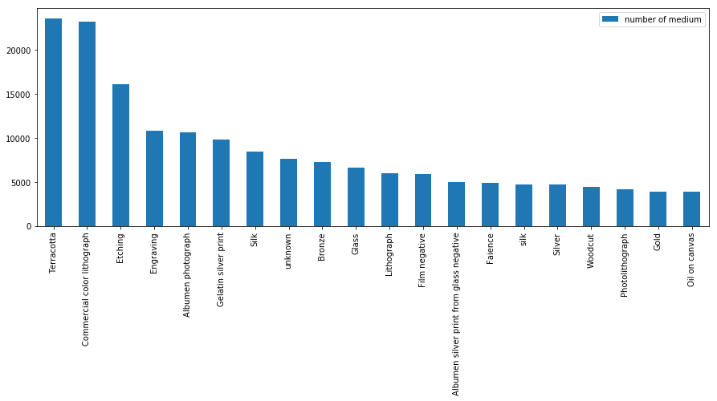

```python
mediums=[]
number=[]
for i in range(20):
    mediums.append(summary_statistics_medium[i][0])
    number.append(summary_statistics_medium[i][1])
df_3=pd.DataFrame(number,mediums,columns=['number of medium'])
df_3.plot(kind='bar',figsize=(15,5))
```

Clean the data of region here. Delete those "unknown_place" since they are too many and they are not meaningful

```python
regions=[]
museum=museum.fillna({'Region':'unknown_place'})
for i in range(len(museum['Region'])):
    regex=re.compile(r'\w+')
    a=regex.findall(museum['Region'][i])
    if a==['unknown_place']:
        pass
    else:
        regions.append(''.join(a))
```

Counts regions

```python
set_regions=set(regions)
d={}
for item in set_regions:
     d.update({item:regions.count(item)})
summary_statistics_region = sorted(d.items(), key=lambda x: x[1], reverse=True)
summary_statistics_region
```

make chart plot. UpperEgyptThebes occurs the most

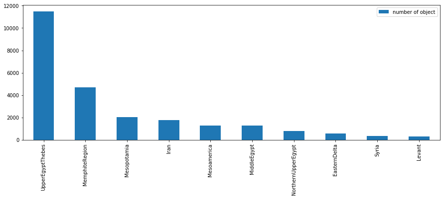

```python
region=[]
number=[]
for i in range(10):
    region.append(summary_statistics_region[i][0])
    number.append(summary_statistics_region[i][1])
df_2=pd.DataFrame(number,region,columns=['number of object'])
df_2.plot(kind='bar',figsize=(15,5))
```

Use bar chart to show the ratio of pubilc and personal

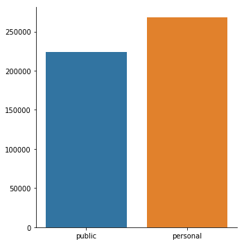

```python
a=museum['Is Public Domain'].value_counts()
data={'public':a[1],'personal':a[0]}
df=pd.DataFrame(data,index=[0])
plt.figure(figsize=(15,5))
sns.catplot(kind="bar", data=df)
```

Compare if a stuff highlight or not in bar chart

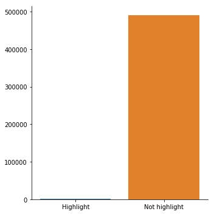

```python
a=museum['Is Highlight'].value_counts()
data={'Highlight':a[1],'Not highlight':a[0]}
df=pd.DataFrame(data,index=[0])
sns.catplot(kind="bar", data=df)
```